# Machine Learning Project WriteUp

Saturday, December 13, 2014

The goal of your project is to predict the manner in which the the exercise was performed. A high level analysis need to be conducted to undersdtand the data, followed up by cleanup and attempt at isolating predictors. Preprocess, train and then go for prediction.

Load libraries

```r
library(caret)
library(kernlab);
library(plyr)
library(reshape2)
library(stats)
```

### Load raw data

```r
## Read Raw Data

##"https://d396qusza40orc.cloudfront.net/predmachlearn/pml-training.csv"
if(!file.exists("pml-training.csv"))
     download.file("https://d396qusza40orc.cloudfront.net/predmachlearn/pml-training.csv","pml-training.csv")

##"https://d396qusza40orc.cloudfront.net/predmachlearn/pml-testing.csv"
if(!file.exists("pml-testing.csv"))
     download.file("https://d396qusza40orc.cloudfront.net/predmachlearn/pml-testing.csv","pml-testing.csv")

srctraining<-read.csv("pml-training.csv")
srctesting<-read.csv("pml-testing.csv")

idtoprd<-grep("classe",names(srctraining))

str(srctraining)
```

```
## 'data.frame':    19622 obs. of  160 variables:
##  $ X                       : int  1 2 3 4 5 6 7 8 9 10 ...
##  $ user_name               : Factor w/ 6 levels "adelmo","carlitos",..: 2 2 2 2 2 2 2 2 2 2 ...
##  $ raw_timestamp_part_1    : int  1323084231 1323084231 1323084231 1323084232 1323084232 1323084232 1323084232 1323084232 1323084232 1323084232 ...
##  $ raw_timestamp_part_2    : int  788290 808298 820366 120339 196328 304277 368296 440390 484323 484434 ...
##  $ cvtd_timestamp          : Factor w/ 20 levels "02/12/2011 13:32",..: 9 9 9 9 9 9 9 9 9 9 ...
##  $ new_window              : Factor w/ 2 levels "no","yes": 1 1 1 1 1 1 1 1 1 1 ...
##  $ num_window              : int  11 11 11 12 12 12 12 12 12 12 ...
##  $ roll_belt               : num  1.41 1.41 1.42 1.48 1.48 1.45 1.42 1.42 1.43 1.45 ...
##  $ pitch_belt              : num  8.07 8.07 8.07 8.05 8.07 8.06 8.09 8.13 8.16 8.17 ...
##  $ yaw_belt                : num  -94.4 -94.4 -94.4 -94.4 -94.4 -94.4 -94.4 -94.4 -94.4 -94.4 ...
##  $ total_accel_belt        : int  3 3 3 3 3 3 3 3 3 3 ...
##  $ kurtosis_roll_belt      : Factor w/ 397 levels "","-0.016850",..: 1 1 1 1 1 1 1 1 1 1 ...
##  $ kurtosis_picth_belt     : Factor w/ 317 levels "","-0.021887",..: 1 1 1 1 1 1 1 1 1 1 ...
##  $ kurtosis_yaw_belt       : Factor w/ 2 levels "","#DIV/0!": 1 1 1 1 1 1 1 1 1 1 ...
```

[output cut: 86 more lines]

### Data preparation

Multiple techniques to preprocess, whcih ever technique used take model from train and apply it on test. Don’t reanalyze test data. Guidance here http://topepo.github.io/caret/preprocess.html. We will start with eliminating nearZeroVar columns.

```r
##Eliminate near zero variance variables
nzv <- nearZeroVar(srctraining[,-idtoprd], saveMetrics = TRUE)
nzvCols<-rownames(nzv[nzv$nzv==TRUE|nzv$zeroVar==TRUE,])

#remove navCols
indNzvCols<-unlist(sapply(nzvCols,function(x){grep(x,names(srctraining))},USE.NAMES=F))
trData<-srctraining[,-indNzvCols]
idtoprd<-grep("classe",names(trData))
```

Based on the above output looks like ther are quite a few columns that have NA. Ther are two possible options, one is to use clean.cases other is to exclude some columns. Since we are dealing with upward of 100 columns will go with remvoing any column tha has NA.

```r
naCols <- sapply(srctraining, function (x) any(is.na(x) | x == ""))
missingDataCols<-names(srctraining)[naCols]

##combine this to the list of nzv cols and keep it aside to be applied on testing dataset
colsToExclude<-unique(rbind(nzvCols,missingDataCols))
```

Next step is to select “belt”, “forearm”, “arm”, “dumbbell” based data columns

```r
#remove navCols
ff<-function(x){
        print(x)
        grep(x,names(srctraining))
        }
indRmvCols<-unlist(unique(sapply(colsToExclude,function(x){grep(x,names(srctraining))})))

trData<-srctraining[,-indRmvCols]
idtoprd<-grep("classe",names(trData))

#Check to see what our tr data looks like after excluding nav and na cols

probCols<-c("belt", "forearm", "arm", "dumbbell")

prCols<-unique(unlist(sapply(probCols,function(x){names(trData)[grep(x,names(trData))]})))
prColsIdx<-unique(unlist(sapply(probCols,function(x){grep(x,names(trData))})))
prColsIdx[length(prColsIdx)+1]<-idtoprd
trData<-trData[,prColsIdx]


str(trData)
```

```
## 'data.frame':    19622 obs. of  53 variables:
##  $ roll_belt           : num  1.41 1.41 1.42 1.48 1.48 1.45 1.42 1.42 1.43 1.45 ...
##  $ pitch_belt          : num  8.07 8.07 8.07 8.05 8.07 8.06 8.09 8.13 8.16 8.17 ...
##  $ yaw_belt            : num  -94.4 -94.4 -94.4 -94.4 -94.4 -94.4 -94.4 -94.4 -94.4 -94.4 ...
##  $ total_accel_belt    : int  3 3 3 3 3 3 3 3 3 3 ...
##  $ gyros_belt_x        : num  0 0.02 0 0.02 0.02 0.02 0.02 0.02 0.02 0.03 ...
##  $ gyros_belt_y        : num  0 0 0 0 0.02 0 0 0 0 0 ...
##  $ gyros_belt_z        : num  -0.02 -0.02 -0.02 -0.03 -0.02 -0.02 -0.02 -0.02 -0.02 0 ...
##  $ accel_belt_x        : int  -21 -22 -20 -22 -21 -21 -22 -22 -20 -21 ...
##  $ accel_belt_y        : int  4 4 5 3 2 4 3 4 2 4 ...
##  $ accel_belt_z        : int  22 22 23 21 24 21 21 21 24 22 ...
##  $ magnet_belt_x       : int  -3 -7 -2 -6 -6 0 -4 -2 1 -3 ...
##  $ magnet_belt_y       : int  599 608 600 604 600 603 599 603 602 609 ...
##  $ magnet_belt_z       : int  -313 -311 -305 -310 -302 -312 -311 -313 -312 -308 ...
##  $ roll_forearm        : num  28.4 28.3 28.3 28.1 28 27.9 27.9 27.8 27.7 27.7 ...
```

[output cut: 39 more lines]

### Out of Sample Error consideration

In order to minmize out of sample error we will split the source training dataset into a training set and validation test set. By using an algorithm like RandomForest the training set prediction is going to be high but need to watch for overfitting.

```r
set.seed(8309)
idtoprd<-grep("classe",names(trData))
inTrain<-createDataPartition(y=trData$classe,
                               p=0.7, list=FALSE)

training <- trData[inTrain,]
testing <- trData[-inTrain,]
```

### Conduct some eploratory analysis using boxplot

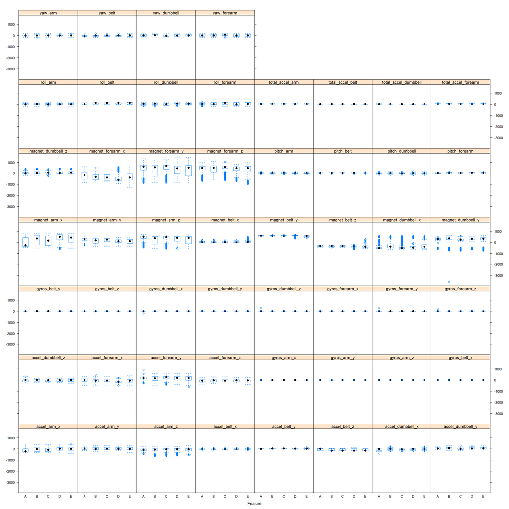

```r
featurePlot(training[,-idtoprd],training$classe,plot="box")
```

### Preprocessing

At this point looks like columns have been narrowed down to what we need, so we can proceed to preprocessing. Based on the box plot data has large range, will need to scale and center as a part of preprocessing.

```r
preProc <- preProcess(training[,-idtoprd],method=c("scale","center"))
trainPC <- predict(preProc,training[,-idtoprd])
```

#### Create another feature plot to see if there are any outliers

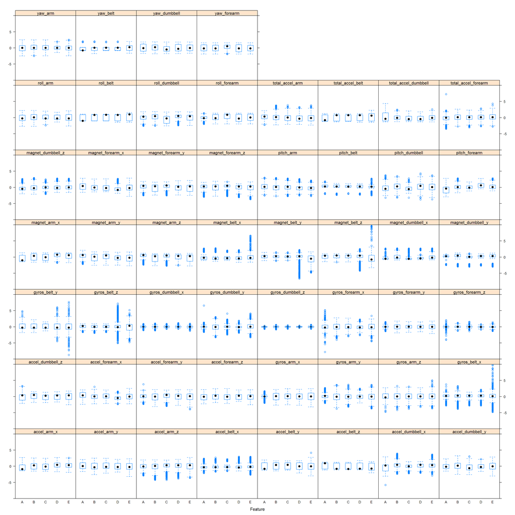

```r
featurePlot(trainPC[,-idtoprd],training$classe,plot="box",ylim=c(-10,10))
```

### Training

Build a training model using the Randomforest method.

```r
modelFit <- train(training$classe ~ .,method="rf",data=trainPC)
```

Review the Model

```r
summary(modelFit$finalModel)
```

```
##                 Length Class      Mode
## call                4  -none-     call
## type                1  -none-     character
## predicted       13737  factor     numeric
## err.rate         3000  -none-     numeric
## confusion          30  -none-     numeric
## votes           68685  matrix     numeric
## oob.times       13737  -none-     numeric
## classes             5  -none-     character
## importance         52  -none-     numeric
## importanceSD        0  -none-     NULL
## localImportance     0  -none-     NULL
## proximity           0  -none-     NULL
## ntree               1  -none-     numeric
## mtry                1  -none-     numeric
## forest             14  -none-     list
## y               13737  factor     numeric
## test                0  -none-     NULL
## inbag               0  -none-     NULL
## xNames             52  -none-     character
## problemType         1  -none-     character
## tuneValue           1  data.frame list
## obsLevels           5  -none-     character
```

```r
modelFit$finalModel
```

```
##
## Call:
##  randomForest(x = x, y = y, mtry = param$mtry)
##                Type of random forest: classification
##                      Number of trees: 500
## No. of variables tried at each split: 2
##
##         OOB estimate of  error rate: 0.68%
## Confusion matrix:
##      A    B    C    D    E class.error
## A 3901    5    0    0    0 0.001280082
## B   18 2634    6    0    0 0.009029345
## C    0   21 2373    2    0 0.009599332
## D    0    0   34 2216    2 0.015985790
## E    0    0    0    5 2520 0.001980198
```

```r
varImp(modelFit)
```

```
## rf variable importance
##
##   only 20 most important variables shown (out of 52)
##
##                      Overall
## roll_belt             100.00
## yaw_belt               83.28
## magnet_dumbbell_z      70.94
## pitch_forearm          64.65
## magnet_dumbbell_y      64.56
## pitch_belt             59.51
## magnet_dumbbell_x      54.39
## roll_forearm           52.50
## accel_dumbbell_y       44.66
## magnet_belt_z          44.58
## magnet_belt_y          43.77
## roll_dumbbell          41.65
## accel_belt_z           41.35
## accel_dumbbell_z       38.16
## roll_arm               34.85
## accel_forearm_x        30.56
## accel_dumbbell_x       30.19
## magnet_arm_x           28.83
## gyros_belt_z           28.48
## total_accel_dumbbell   28.01
```

### Model validation

```r
testPC <- predict(preProc,testing[,-idtoprd])
confusionMatrix(testing$classe,predict(modelFit,testPC))
```

```
## Confusion Matrix and Statistics
##
##           Reference
## Prediction    A    B    C    D    E
##          A 1673    1    0    0    0
##          B    3 1133    3    0    0
##          C    0   10 1015    1    0
##          D    0    0   13  949    2
##          E    0    0    0    3 1079
##
## Overall Statistics
##
##                Accuracy : 0.9939
##                  95% CI : (0.9915, 0.9957)
##     No Information Rate : 0.2848
##     P-Value [Acc > NIR] : < 2.2e-16
##
##                   Kappa : 0.9923
##  Mcnemar's Test P-Value : NA
##
## Statistics by Class:
##
##                      Class: A Class: B Class: C Class: D Class: E
## Sensitivity            0.9982   0.9904   0.9845   0.9958   0.9981
## Specificity            0.9998   0.9987   0.9977   0.9970   0.9994
## Pos Pred Value         0.9994   0.9947   0.9893   0.9844   0.9972
## Neg Pred Value         0.9993   0.9977   0.9967   0.9992   0.9996
## Prevalence             0.2848   0.1944   0.1752   0.1619   0.1837
## Detection Rate         0.2843   0.1925   0.1725   0.1613   0.1833
## Detection Prevalence   0.2845   0.1935   0.1743   0.1638   0.1839
## Balanced Accuracy      0.9990   0.9946   0.9911   0.9964   0.9988
```

Save the model so that we can use it for testing later

```r
save(modelFit, file="MLRForsetModel.RData")
```

#### Run the model against the provided test set

```r
load(file="MLRForsetModel.RData", verbose=TRUE)
```

```
## Loading objects:
##   modelFit
```

```r
submissionTest<-read.csv("pml-testing.csv")

##Preprocess steps similar to training set, start with isolating coloumns

submissionTest<-submissionTest[,-indRmvCols]
submissionTest<-submissionTest[,prColsIdx]
names(submissionTest)
```

```
##  [1] "roll_belt"            "pitch_belt"           "yaw_belt"
##  [4] "total_accel_belt"     "gyros_belt_x"         "gyros_belt_y"
##  [7] "gyros_belt_z"         "accel_belt_x"         "accel_belt_y"
## [10] "accel_belt_z"         "magnet_belt_x"        "magnet_belt_y"
## [13] "magnet_belt_z"        "roll_forearm"         "pitch_forearm"
## [16] "yaw_forearm"          "total_accel_forearm"  "gyros_forearm_x"
## [19] "gyros_forearm_y"      "gyros_forearm_z"      "accel_forearm_x"
## [22] "accel_forearm_y"      "accel_forearm_z"      "magnet_forearm_x"
## [25] "magnet_forearm_y"     "magnet_forearm_z"     "roll_arm"
## [28] "pitch_arm"            "yaw_arm"              "total_accel_arm"
## [31] "gyros_arm_x"          "gyros_arm_y"          "gyros_arm_z"
## [34] "accel_arm_x"          "accel_arm_y"          "accel_arm_z"
## [37] "magnet_arm_x"         "magnet_arm_y"         "magnet_arm_z"
## [40] "roll_dumbbell"        "pitch_dumbbell"       "yaw_dumbbell"
## [43] "total_accel_dumbbell" "gyros_dumbbell_x"     "gyros_dumbbell_y"
## [46] "gyros_dumbbell_z"     "accel_dumbbell_x"     "accel_dumbbell_y"
## [49] "accel_dumbbell_z"     "magnet_dumbbell_x"    "magnet_dumbbell_y"
## [52] "magnet_dumbbell_z"    "problem_id"
```

```r
testPC <- predict(preProc,submissionTest[,-idtoprd])
answers<-predict(modelFit,testPC)
answers
```

```
##  [1] B A B A A E D B A A B C B A E E A B B B
## Levels: A B C D E
```

```r
results<-cbind(submissionTest$problem_id,as.character(answers))
results
```

```
##       [,1] [,2]
##  [1,] "1"  "B"
##  [2,] "2"  "A"
##  [3,] "3"  "B"
##  [4,] "4"  "A"
##  [5,] "5"  "A"
##  [6,] "6"  "E"
##  [7,] "7"  "D"
##  [8,] "8"  "B"
##  [9,] "9"  "A"
## [10,] "10" "A"
## [11,] "11" "B"
## [12,] "12" "C"
## [13,] "13" "B"
## [14,] "14" "A"
## [15,] "15" "E"
## [16,] "16" "E"
## [17,] "17" "A"
## [18,] "18" "B"
## [19,] "19" "B"
## [20,] "20" "B"
```

Save answers to a file per the guidlines in the project

```r
pml_write_files = function(x){
  n = length(x)
  for(i in 1:n){
    filename = paste0("problem_id_",i,".txt")
    write.table(x[i],file=filename,quote=FALSE,row.names=FALSE,col.names=FALSE)
  }
}

setwd("./Assignment")
pml_write_files(answers)
setwd("..")
```